# R Training: 99 - R Markdowns

Pricing Innovation Team

### Embedding R Code

You can embed an R code chunk by either pressing insert or through the keyboard shortcutCtrl + Alt + I:

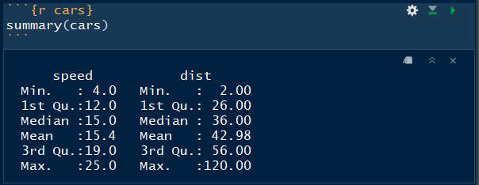

R Markdown Code Chunks

As we can see using this chunk will allow us to show our code within our report as well as the results of our analysis

```
     speed           dist
 Min.   : 4.0   Min.   :  2.00
 1st Qu.:12.0   1st Qu.: 26.00
 Median :15.0   Median : 36.00
 Mean   :15.4   Mean   : 42.98
 3rd Qu.:19.0   3rd Qu.: 56.00
 Max.   :25.0   Max.   :120.00
```

Normally in reports we want to be able to show plots which Rmarkdown allows your to do as well

### Including Plots

You can also embed plots, such as the previous plots seen using plotly. These will be embedded in the html file allowing for a good way to present results.

Below is a simple example using the basic plotting function, however any of our previous plots using plotly or ggplot2 could be used instead.

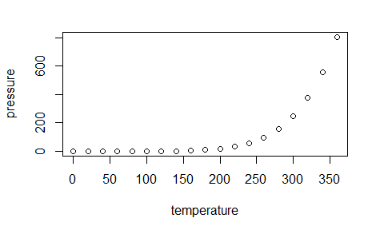

### Titles and subtitles

“# can be used to create more and more titles of a text. Starting with # and then ## we can consecutively add more to create more and more subsections”

## A

### B

#### C

We can also use bolds and italics as well as other formatting that can be found in this sheet.

[R Markdown Basics](https://rmarkdown.rstudio.com/authoring_basics.html)

### Conclusion

While this was only supposed to be an introduction on how to make rmarkdowns, you can see an rmarkdown file is really easy to generate and present results with